# Introduction to Data Analysis and Visualization

Kuo, Yao-Jen, 2020-07-11

> [slido](https://www.sli.do/) #54913

> https://bit.ly/2Od6rzs

> [binder](https://mybinder.org/v2/gh/yaojenkuo/talks/master)

## TL; DR

> In this talk, we are gonna briefly introduce what is data analysis and visualization with modern data science approach.

## About me

## A data enthusiast and instructor focused on practical Python/R/SQL

## Teaching practical data science online/offline

- [如何成為資料分析師：從問題解決到行動方案，Hahow 好學校](https://hahow.in/cr/dajourney)
- Visualization and modern data science, Adjunct Instructor, National Taiwan University
- Python for data analysis, Instructor, Chunghwa Telecom Academy
- Python for data science, Machine learning from scratch, Senior Instructor, CSIE Train, National Taiwan University

## Data science instructor focused on commercial banking clients

- 2020 DBS Python Training Program
- 2019 HNCB Python Training Program
- 2017 ESUN Python Training Program

## Writing books on data science

- [輕鬆學習 R 語言](https://www.books.com.tw/products/0010835361)
- [進擊的資料科學](https://www.books.com.tw/products/0010827812)
- [新手村逃脫！初心者的 Python 機器學習攻略](https://yaojenkuo.io/ml-newbies/index.html)

## Writing tutorials on [Medium](https://medium.com/) with 3k+ followers

- Follow my Medium account @tonykuoyj
- Or, follow my publication [DataInPoint](https://medium.com/datainpoint)
- Or, follow [DataInPoint](https://www.facebook.com/datainpoint) on Facebook

## Working experience and eductation

- Working experience
  - Senior Data Analyst, Coupang Shanghai
  - Analytical Consultant, SAS Taiwan
  - Management Associate, Chinatrust Banking Corporation Taiwan
  - Research Assistant, McKinsey & Company Taiwan
- Education
  - MBA, National Taiwan University
  - BA, National Taiwan University

## Loves running with a marathon PR of 2:43:12 at 2019 Seoul Marathon

## Future initiatives

Make DataInPoint a text-based, in-browser, and subscription-only data science bootcamp.

## What is data analysis

## The definition

> We generate questions about a specific topic, we search for answers by exploring, transforming, and modelling data referring to our topic. And then use what we've learned to refine questions or generate new questions.

Source: [R for Data Science](https://r4ds.had.co.nz/)

## Why data analysis

> It is now an era of data-driven strategic thinking, and is probably never coming back.

## The three means of persuasion that an orator must rely on

- ethos
- pathos
- logos

Source: [Aristotle, Rhetoric](https://en.wikipedia.org/wiki/Rhetoric)

## It is a lot easier to persuade via ethos or pathos, but it takes time

However, logos can be easily acquired once it is a fact and can be proven. Hence, data analysis is often the express way to logos.

## Let's bring up a topic NOW

> 大選開票看哪個里最準？ 「章魚里」神預測告訴你。每次到了選舉，總是會有幾個里開票與大選結果相似，因此被各界視為重點關注的開票區域。

Source: https://www.cw.com.tw/article/5093012

## We can then generate some questions regarding this topic

- How to define 「章魚里」?
- Can we find out 「章魚里」 based on 2020 presidential data?
- Can we find the similarity of our own village?

## We'll do this later, now you've got the idea of data analysis, let's move on

## What is visualization

## The definition

> Visualization is a tool that addresses the gap between data, function, formula, and viewers. Effective visualizations transform abstract collections of numbers into shapes that viewers quickly grasp and understand.

Source: [Data Visualization with JavaScript](https://www.amazon.com/Data-Visualization-JavaScript-Stephen-Thomas-ebook/dp/B00V20IFDG)

## Why visualization

## What are $x$ and $f$

```python
print(x)
print(f)
```

```
[ 0.          0.25645654  0.51291309  0.76936963  1.02582617  1.28228272
  1.53873926  1.7951958   2.05165235  2.30810889  2.56456543  2.82102197
  3.07747852  3.33393506  3.5903916   3.84684815  4.10330469  4.35976123
  4.61621778  4.87267432  5.12913086  5.38558741  5.64204395  5.89850049
  6.15495704  6.41141358  6.66787012  6.92432667  7.18078321  7.43723975
  7.69369629  7.95015284  8.20660938  8.46306592  8.71952247  8.97597901
  9.23243555  9.4888921   9.74534864 10.00180518 10.25826173 10.51471827
 10.77117481 11.02763136 11.2840879  11.54054444 11.79700098 12.05345753
 12.30991407 12.56637061]
[ 0.00000000e+00  2.53654584e-01  4.90717552e-01  6.95682551e-01
  8.55142763e-01  9.58667853e-01  9.99486216e-01  9.74927912e-01
  8.86599306e-01  7.40277997e-01  5.45534901e-01  3.15108218e-01
  6.40702200e-02 -1.91158629e-01 -4.33883739e-01 -6.48228395e-01
 -8.20172255e-01 -9.38468422e-01 -9.95379113e-01 -9.87181783e-01
 -9.14412623e-01 -7.81831482e-01 -5.98110530e-01 -3.75267005e-01
 -1.27877162e-01  1.27877162e-01  3.75267005e-01  5.98110530e-01
  7.81831482e-01  9.14412623e-01  9.87181783e-01  9.95379113e-01
  9.38468422e-01  8.20172255e-01  6.48228395e-01  4.33883739e-01
  1.91158629e-01 -6.40702200e-02 -3.15108218e-01 -5.45534901e-01
 -7.40277997e-01 -8.86599306e-01 -9.74927912e-01 -9.99486216e-01
 -9.58667853e-01 -8.55142763e-01 -6.95682551e-01 -4.90717552e-01
 -2.53654584e-01 -4.89858720e-16]
```

## $f(x)=sin(x), \text{where } 0 \leq x \leq 4\pi$

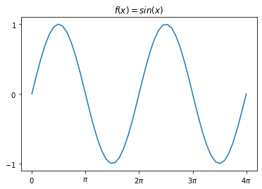

```python
plot_sinx(x, f)
```

## What does the following formula stand for

$$\sigma(z) = \frac{1}{1 + e^{-z}}$$

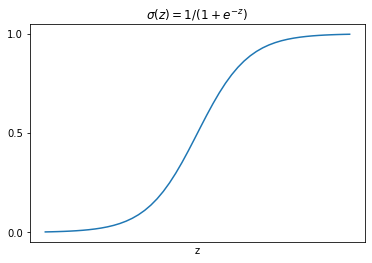

```python
plot_sigmoid(x, S)
```

## Visualization also plays a key role in machine learning

## Machine learning engineer uses line plot to visualize loss function

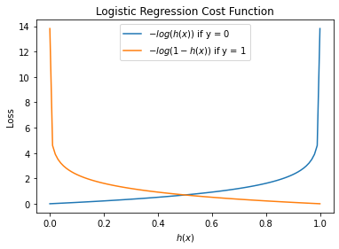

```python
plot_logistic_loss_function(x)
```

## Machine learning engineer uses surface plot to visualize gradients

[figure not shown]

Source: [Coursera | Machine Learning](https://www.coursera.org/learn/machine-learning)

## Machine learning engineer also uses contour plot to visualize gradients

[figure not shown]

Source: [Coursera | Machine Learning](https://www.coursera.org/learn/machine-learning)

## Machine learning engineer uses scatter plot and contour plot to visualize decision boundary

Source: https://scikit-learn.org/stable/auto_examples/ensemble/plot_voting_decision_regions.html#sphx-glr-auto-examples-ensemble-plot-voting-decision-regions-py

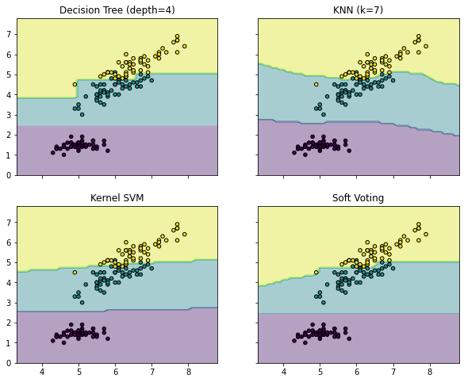

```python
plot_multiple_decision_boundary()
```

## It is also best practice to visualize decision boundary for deep learning models

[figure not shown]

Source: https://playground.tensorflow.org/

## The 2 most influential visualizations of ALL TIME

1. [Minard's map of Napoleon's disastrous Russian campaign of 1812](https://en.wikipedia.org/wiki/Flow_map#/media/File:Minard.png)
2. [Hans Rosling's 200 Countries, 200 Years, 4 Minutes](https://youtu.be/jbkSRLYSojo)

## [Minard's map of Napoleon's disastrous Russian campaign of 1812](https://en.wikipedia.org/wiki/Flow_map#/media/File:Minard.png)

In 1812, Napoleon marched to Moscow. 98% of his soldiers died. The simple but fascinating temperature line below the viz shows how cold ultimately defeated Napoleon’s army.

[figure not shown]

## [Hans Rosling's 200 Countries, 200 Years, 4 Minutes](https://youtu.be/jbkSRLYSojo)

A 2007 TED talk for the Swedish scientist shared his passion with the world. It shows the relationship between wealth and health.

[figure not shown]

> The simple graph has brought more information to the data analyst’s mind than any other device.

> [John Tukey](https://en.wikipedia.org/wiki/John_Tukey)

## [John Tukey](https://en.wikipedia.org/wiki/John_Tukey) is an American mathematician best known for development of box plot.

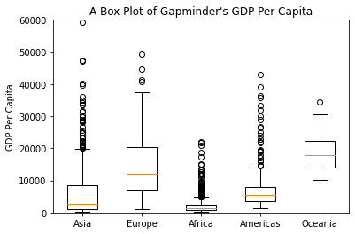

```python
plot_box_plot(gapminder)
```

## What is modern data science

> Modern data science is a huge field, it invovles applications and tools like importing, tidying, transformation, visualization, modeling, and communication. Surrounding all these is programming.

[figure not shown]

Source: [R for Data Science](https://r4ds.had.co.nz/)

[figure not shown]

Source: https://twitter.com/cdixon/status/428914681911070720/photo/1

[figure not shown]

Source: http://drewconway.com/

## Meet my favorite data scientist on TV show: Chandler Bing

[figure not shown]

Source: https://gph.is/g/4DA0wGO

[figure not shown]

Source: https://www.warnerbros.com/tv/friends/

[figure not shown]

Source: https://www.warnerbros.com/tv/friends/

## In fact, Python(or R, Julia, Matlab ...etc.) is capable to tackle everything

[figure not shown]

Source: [R for Data Science](https://r4ds.had.co.nz/)

## So it is inevitable to write codes in modern data science

## What does it take to write a program

[figure not shown]

Source: https://en.wikipedia.org/wiki/File:Archimedes_lever_(Small).jpg

## Text editors and interpreter/compiler are your points of support!

## Let's explore 3 questions in [2019 Kaggle ML & DS Survey](https://www.kaggle.com/c/kaggle-survey-2019)

- Q14: What is the primary tool that you use at work or school to analyze data?
- Q18: What programming languages do you use on a regular basis?
- Q19: What programming language would you recommend an aspiring data scientist to learn first?

## What is [Kaggle](https://kaggle.com/)

> A subsidiary of Google, is an online community of data scientists and machine learning practitioners. Kaggle allows users to find and publish data sets, explore and build models in a web-based data-science environment, work with other data scientists and machine learning engineers, and enter competitions to solve data science challenges.

Source: https://en.wikipedia.org/wiki/Kaggle

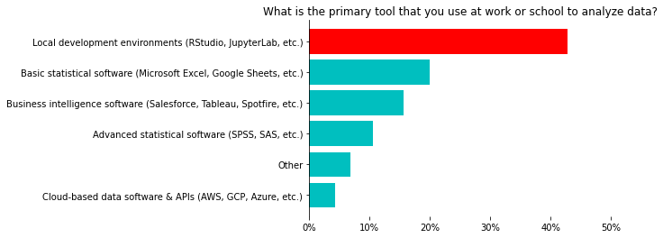

```python
# What is the primary tool that you use at work or school to analyze data?
plot_ans_14(ans_14)
```

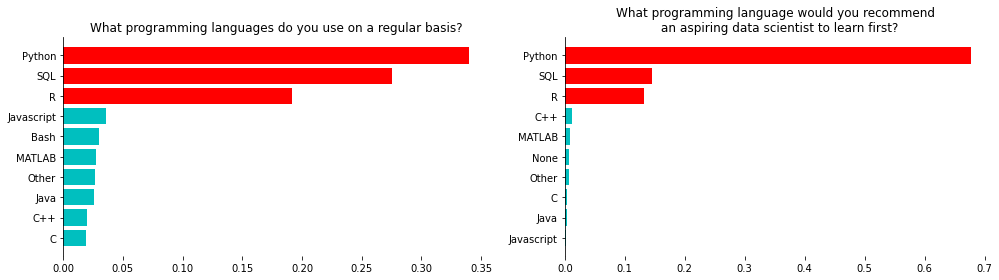

```python
# What programming languages do you use on a regular basis?
# What programming language would you recommend an aspiring data scientist to learn first?
plot_ans_18_19(ans_18, ans_19)
```

## Now you've got what data analysis, visualization, and modern data science are

## We can answer our questions using a bit of technical assists

- How to define 「章魚里」?
- Can we find out 「章魚里」 based on 2020 presidential data?
- Can we find the similarity of our own village?

## How to define 「章魚里」

Basically, after a few literature search, you may find the definition of 「章魚里」 is quite ambigious. So we are using a much fancier metric: **cosine similarity**.

## What is cosine similarity

> Cosine similarity is a measure of similarity between two non-zero vectors of an inner product space. It is defined to equal the cosine of the angle between them, which is also the same as the inner product of the same vectors normalized to both have length 1.

\begin{equation} a = (a_1, a_2, a_3) \\ b = (b_1, b_2, b_3) \end{equation}\begin{align} cos\theta &= \frac{\sum_i(a_i \times b_i)}{\sqrt{\sum_i a_i^2} \times \sqrt{\sum_i b_i^2}} \\ &= \frac{a \cdot b}{\parallel a \parallel \times \parallel b \parallel} \end{align}

Source: [Cosine similarity](https://en.wikipedia.org/wiki/Cosine_similarity)

## Can we find out 「章魚里」 based on 2020 presidential data

Definitely, we all have access to [Central Election Commission](https://db.cec.gov.tw/).

## Now we have to write code to integrate these spreadsheets.

```python
from presidential import Presidential

presidential = Presidential('presidential-2020')
presidential_df = presidential.adjust_presidential_df()
```

```
Tidying 總統-A05-4-候選人得票數一覽表-各投開票所(宜蘭縣).xls
Tidying 總統-A05-4-候選人得票數一覽表-各投開票所(彰化縣).xls
Tidying 總統-A05-4-候選人得票數一覽表-各投開票所(金門縣).xls
Tidying 總統-A05-4-候選人得票數一覽表-各投開票所(桃園市).xls
Tidying 總統-A05-4-候選人得票數一覽表-各投開票所(苗栗縣).xls
Tidying 總統-A05-4-候選人得票數一覽表-各投開票所(臺南市).xls
Tidying 總統-A05-4-候選人得票數一覽表-各投開票所(雲林縣).xls
Tidying 總統-A05-4-候選人得票數一覽表-各投開票所(南投縣).xls
Tidying 總統-A05-4-候選人得票數一覽表-各投開票所(高雄市).xls
Tidying 總統-A05-4-候選人得票數一覽表-各投開票所(臺北市).xls
Tidying 總統-A05-4-候選人得票數一覽表-各投開票所(新北市).xls
Tidying 總統-A05-4-候選人得票數一覽表-各投開票所(花蓮縣).xls
Tidying 總統-A05-4-候選人得票數一覽表-各投開票所(新竹市).xls
Tidying 總統-A05-4-候選人得票數一覽表-各投開票所(新竹縣).xls
Tidying 總統-A05-4-候選人得票數一覽表-各投開票所(基隆市).xls
Tidying 總統-A05-4-候選人得票數一覽表-各投開票所(連江縣).xls
Tidying 總統-A05-4-候選人得票數一覽表-各投開票所(嘉義縣).xls
Tidying 總統-A05-4-候選人得票數一覽表-各投開票所(嘉義市).xls
Tidying 總統-A05-4-候選人得票數一覽表-各投開票所(屏東縣).xls
Tidying 總統-A05-4-候選人得票數一覽表-各投開票所(澎湖縣).xls
Tidying 總統-A05-4-候選人得票數一覽表-各投開票所(臺東縣).xls
Tidying 總統-A05-4-候選人得票數一覽表-各投開票所(臺中市).xls
```

```python
presidential_df.head()
```

|  | county | town | village | office | number | candidate | votes |
| --- | --- | --- | --- | --- | --- | --- | --- |
| 0 | 宜蘭縣 | 宜蘭市 | 民族里 | 1 | 1 | 宋楚瑜/余湘 | 37 |
| 1 | 宜蘭縣 | 宜蘭市 | 民族里 | 2 | 1 | 宋楚瑜/余湘 | 31 |
| 2 | 宜蘭縣 | 宜蘭市 | 建軍里 | 3 | 1 | 宋楚瑜/余湘 | 19 |
| 3 | 宜蘭縣 | 宜蘭市 | 建軍里 | 4 | 1 | 宋楚瑜/余湘 | 29 |
| 4 | 宜蘭縣 | 宜蘭市 | 泰山里 | 5 | 1 | 宋楚瑜/余湘 | 25 |

```python
presidential_df.tail()
```

|  | county | town | village | office | number | candidate | votes |
| --- | --- | --- | --- | --- | --- | --- | --- |
| 51673 | 臺中市 | 和平區 | 梨山里 | 1845 | 3 | 蔡英文/賴清德 | 132 |
| 51674 | 臺中市 | 和平區 | 梨山里 | 1846 | 3 | 蔡英文/賴清德 | 107 |
| 51675 | 臺中市 | 和平區 | 梨山里 | 1847 | 3 | 蔡英文/賴清德 | 40 |
| 51676 | 臺中市 | 和平區 | 平等里 | 1848 | 3 | 蔡英文/賴清德 | 24 |
| 51677 | 臺中市 | 和平區 | 平等里 | 1849 | 3 | 蔡英文/賴清德 | 102 |

## Check if the summations are right

```python
ttl_votes = presidential_df['votes'].sum()
ttl_votes_by_candidates = presidential_df.groupby('number')['votes'].sum()
ttl_votes_by_candidates
```

```
number
1     608590
2    5522119
3    8170231
Name: votes, dtype: int64
```

## National percentage is our target vector to be compared

```python
national_percentage = ttl_votes_by_candidates / ttl_votes
national_percentage
```

```
number
1    0.042556
2    0.386137
3    0.571307
Name: votes, dtype: float64
```

## Total votes for each village

```python
combined_key = presidential_df['county'].str.cat(presidential_df['town']).str.cat(presidential_df['village'])
presidential_df = presidential_df.assign(combined_key=combined_key)
ttl_votes_by_combined_key = presidential_df.groupby(['combined_key'])['votes'].sum()
ttl_votes_by_combined_key
```

```
combined_key
南投縣中寮鄉中寮村      443
南投縣中寮鄉內城村      297
南投縣中寮鄉八仙村      535
南投縣中寮鄉和興村      422
南投縣中寮鄉崁頂村      304
             ...
高雄市鼓山區鼓岩里      847
高雄市鼓山區鼓峰里     1425
高雄市鼓山區龍井里      906
高雄市鼓山區龍子里    11410
高雄市鼓山區龍水里    16333
Name: votes, Length: 7737, dtype: int64
```

## Votes percentage by each candidate and village

```python
ttl_votes_by_combined_key_candidates = presidential_df.groupby(['combined_key', 'number'])['votes'].sum()
soong = ttl_votes_by_combined_key_candidates[:, '1'] / ttl_votes_by_combined_key
han = ttl_votes_by_combined_key_candidates[:, '2'] / ttl_votes_by_combined_key
tsai = ttl_votes_by_combined_key_candidates[:, '3'] / ttl_votes_by_combined_key
votes_obtained = pd.concat([soong, han, tsai], axis=1)
votes_obtained.columns = ['soong', 'han', 'tsai']
```

```python
votes_obtained
```

| combined_key | soong | han | tsai |
| --- | --- | --- | --- |
| 南投縣中寮鄉中寮村 | 0.040632 | 0.489842 | 0.469526 |
| 南投縣中寮鄉內城村 | 0.057239 | 0.474747 | 0.468013 |
| 南投縣中寮鄉八仙村 | 0.039252 | 0.435514 | 0.525234 |
| 南投縣中寮鄉和興村 | 0.021327 | 0.500000 | 0.478673 |
| 南投縣中寮鄉崁頂村 | 0.052632 | 0.381579 | 0.565789 |
| ... | ... | ... | ... |
| 高雄市鼓山區鼓岩里 | 0.014168 | 0.309327 | 0.676505 |
| 高雄市鼓山區鼓峰里 | 0.032982 | 0.473684 | 0.493333 |
| 高雄市鼓山區龍井里 | 0.023179 | 0.367550 | 0.609272 |
| 高雄市鼓山區龍子里 | 0.032340 | 0.381420 | 0.586240 |
| 高雄市鼓山區龍水里 | 0.037654 | 0.398947 | 0.563399 |

7737 rows × 3 columns

## Calculate cosine similarity

```python
a = national_percentage.values
a_norm = np.linalg.norm(a)
cos_similarities = []
for i in range(votes_obtained.shape[0]):
    b = votes_obtained.iloc[i, :].values
    b_norm = np.linalg.norm(b)
    ab = np.dot(a, b)
    cos_similarity = np.dot(a, b) / (a_norm*b_norm)
    cos_similarities.append(cos_similarity)
votes_obtained = votes_obtained.assign(cosine_similarity=cos_similarities)
votes_obtained = votes_obtained.reset_index()
```

## Sort by cosine similarity with descending order to find 「章魚里」

```python
votes_obtained.sort_values(['cosine_similarity', 'combined_key'], ascending=[False, True]).head(10)
```

|  | combined_key | soong | han | tsai | cosine_similarity |
| --- | --- | --- | --- | --- | --- |
| 623 | 嘉義縣番路鄉內甕村 | 0.042553 | 0.386018 | 0.571429 | 1.000000 |
| 5609 | 臺南市東區關聖里 | 0.042450 | 0.386295 | 0.571255 | 1.000000 |
| 5196 | 臺南市中西區南門里 | 0.043410 | 0.385460 | 0.571130 | 0.999999 |
| 2889 | 新北市汐止區保長里 | 0.042833 | 0.386847 | 0.570320 | 0.999999 |
| 3122 | 新北市金山區五湖里 | 0.043765 | 0.385632 | 0.570603 | 0.999998 |
| 4910 | 臺北市南港區東新里 | 0.042036 | 0.385298 | 0.572666 | 0.999997 |
| 4852 | 臺北市內湖區西湖里 | 0.041285 | 0.386008 | 0.572707 | 0.999997 |
| 2355 | 新北市中和區清穗里 | 0.041865 | 0.385347 | 0.572788 | 0.999997 |
| 5282 | 臺南市北區重興里 | 0.042837 | 0.384831 | 0.572331 | 0.999997 |
| 2693 | 新北市板橋區景星里 | 0.042515 | 0.387607 | 0.569878 | 0.999996 |

## Can we find the similarity of our own village?

Definitely.

```python
def find_my_village(my_village):
    return votes_obtained[votes_obtained['combined_key'] == my_village]
find_my_village('臺北市中正區文盛里')
```

|  | combined_key | soong | han | tsai | cosine_similarity |
| --- | --- | --- | --- | --- | --- |
| 4759 | 臺北市中正區文盛里 | 0.053518 | 0.426338 | 0.520144 | 0.995611 |

## Last but not least

## So, you are interested in data science, machine learning, or artificial intelligence

How to get started?

## As always, start with the most practical one: programming

- Python
- Using libraries
- Object-oriented programming
- Data structures
- Algorithm

## Learning while doing exercises

- [Learn Python the Hard Way](https://www.amazon.com/Learn-Python-Hard-Way-Introduction/dp/0321884914)
- [Introducing Python](https://www.amazon.com/Introducing-Python-Modern-Computing-Packages/dp/1449359361)
- [DataCamp](https://www.datacamp.com?tap_a=5644-dce66f&tap_s=194899-1fb421&utm_medium=affiliate&utm_source=tonykuo)
- [LeetCode](https://leetcode.com/)
- [HackerRank](https://www.hackerrank.com/)

## Use Python libraries for analysis and visualization

- [Requests](https://requests.readthedocs.io/en/master/) for web scraping
- [NumPy](https://numpy.org/) for multi-dimensional array
- [Pandas](https://pandas.pydata.org/) for dataframe
- [Matplotlib](https://matplotlib.org/) for visualization

## Use Python to learn math and machine learning theory

- [The Matrix Calculus You Need For Deep Learning](https://explained.ai/matrix-calculus/)
- [Linear Algebra](https://ocw.mit.edu/resources/res-18-010-a-2020-vision-of-linear-algebra-spring-2020/)
- [Machine Learning](https://www.coursera.org/learn/machine-learning)
- [Machine Learning(Hung-yi Lee, NTU)](https://www.youtube.com/playlist?list=PLJV_el3uVTsPy9oCRY30oBPNLCo89yu49)
- [Deep Learning](https://www.deeplearningbook.org/)

## Use R to learn statistics

- [The Art of R Programming](https://www.amazon.com/Art-Programming-Statistical-Software-Design/dp/1593273843)
- [Advanced R](https://adv-r.hadley.nz/)
- [Data Science Specialization](https://www.coursera.org/specializations/jhu-data-science)
- [Statistics with R Specialization](https://www.coursera.org/specializations/statistics)

## Phew, that is a lot to catch up...

You do not have to finish every course or book from end to end. It is a mix-and-match.

[figure not shown]

Source: https://media.giphy.com/